## **ASSET MANAGEMENT PROCESS**

# Contents

**1.** **Introduction** 3

**1.1** **Objective** 3

**1.2** **Scope** 3

**1.3** **Exceptions** 3

**2.** **Assets** 4

**2.1** **Asset Type** 5

**1.** **Asset management cycle** 5

**2.2** Asset Management Cycle – Process flow 5

**1.1** **Planning** 6

**1.2** **Procurement** 6

**1.4** **Asset Recovery** 7

**1.5** **Asset Maintenance or Repair** 7

**1.6** **Transfer of Assets** 8

**1.7** **Reserved Assets** 8

**1.8** **Retiring Assets** 8

**2.3** Asset Disposal 9

**2.4** Customer Owned Assets 9

**2.5** Reporting 10

**2.6** Asset Audit 10

3. Roles and Responsibility 11

4. References 12

**Version History**

| **Version** | **Changes** | **Prepared by** |
| --- | --- | --- |
| V 1.0 | Initial Draft | Tijo Thomas |

# **Introduction**

The purpose of a procedure document is to institutionalize and formalize the preferred method of maintaining and managing Neudesic Assets. The objective is to have to use unique tools across the company and follow the same repeatable steps which would ensure consistency in data and manage component’s criticality to ensuring optimum efficiency

## **Objective**

Neudesic has established Asset Management Standard Operating Procedure to ensure security of company resources, minimize compliance risks, control costs and to provide clear guidelines to improve efficiency and enable sustainable asset management function throughout the asset lifecycle.

## **Scope**

The processes and guidelines outlined in this document will ensure appropriate procurement, maintenance and disposal of assets and are applicable for any IT equipment as listed below.

Computing Devices: Laptop, Desktop, Server, Storage Disks, Mobile Devices etc.

Networking Devices: Firewall, Router, Switch, Wireless Devices, Printer etc.

Others: Projector, Audio/Video Equipment, PBX, Monitor, Keyboard UPS etc.

## **Exceptions**

This document does not cover non -IT assets client devices, temporary trial devices, rental assets etc.

# **Assets**

## An asset is anything of monetary value that a person or organisation possesses. Assets are classed as IT and not IT Assets.IT assets, whether tangible or intangible, such as licences, hardware, etc., are classified as IT rather than IT Assets. Company Assets should be safeguarded against unauthorised access, use, disclosure, alteration, destruction, and/or theft, which could result in financial loss for the company.

## **Asset Type**

- **IT- Asset**

In information security, an asset is any data, device, or other component of the environment that supports information-related activities. Assets include hardware, software, and confidential information.

- **Non-IT Asset**

In this document, Non -IT asset refers to the assets which is not connected to network and does not have an IP to monitor, example – Admin Assets ,Monitor, mouse etc

# **Asset management cycle**

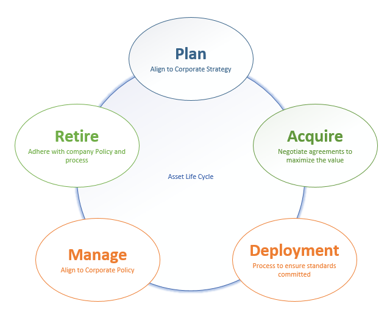

Assets have life cycles and tracking an asset throughout its life cycle is an essential component of any asset management strategy. The asset management process must not only track the asset, but also assist the organisation in transitioning to and preparing for the various phases of the asset's life cycle.

These phases are briefly discussed below, with additional information offered in subsequent parts.

## **Asset Management Cycle – Process flow**

## **Planning**

Quarterly, IT will consult with Business leaders regarding standard asset (laptop) needs and arrange procurement based on stock availability. All other non-standard asset procurement requests and approvals will be handled on a case-by-case basis.

**Procurement Time:** Laptops with ordinary setup have an ETA of 4-6 weeks.

Depending on market and supply chain conditions, this can vary.IT will routinely evaluate market circumstances and business requirements to maintain adequate stock levels.Once the vendor accepts the order, requestors will be notified of the ETA for non-standard assets based on product availability.

**Procurement Type:**

Leasing laptops for three years is being considered.

In most cases, assets will be purchased outright; nevertheless, leases and rentals may be used if necessary and approved by the Chief Technology Officer and the Vice President of Finance.

## **Procurement**

### **Ordering**

1. Assess and validate the business need and demand.
2. Obtain for proposals from vendors.
3. Create a Purchase Order on asset portal with details of business need, device configurations, cost.
4. Request for an approval from the Business Head, CTO & VP, Finance.
5. Once approved, coordinate with Finance Manager to release Purchase Order and then coordinate with the Vendor for delivery.

### **Receiving**

1. Upon delivery of the assets, designated on site Helpdesk team member will validate the assets (especially count, model & specs, warranty, and serial number) and tag.
2. Notify Asset Manager, Asset Coordinator & Finance Department and share the soft copy of Delivery Challan/Invoice. IT will maintain the Delivery Challan for records.
3. Asset Coordinator will update the purchase order as “Items Received” and create a record for each asset in the asset portal.
4. Once the assets are added to the asset portal, Asset Coordinator will update the purchase order as “Closed”.

## **Asset Recovery**

Assets will be recovered, and asset record will be updated in the following scenarios.

1. Employee Exits: Company-issued assets must be returned upon termination of employment or contracts. To ensure timely recovery of assets, HR will notify IT when a resignation is accepted, or a termination is confirmed. IT Follows the Employee Offboarding process to recover the assets. It coordinated with HR if there is any delay in recovering the assets and keep the business informed. As assets are returned by offboarded users, they will be evaluated and will be added back to the stick for re-use.
2. Lost Offers: If an asset has been shipped to a prospective remote employee, coordinate with HCM team and courier partner to recover the laptop.
3. Secondary assets to be recovered when the business need is no longer exist. Project Managers will notify It through a support ticket in these scenarios.
4. Temporary assets will be recovered when the Primary asset has been serviced and Defective assets will be recovered when a laptop replacement is complete.

Once recovered, assets will be validated, and asset records updated.

1. Asset State
2. Notes (add necessary comments)
3. Used by
4. Assigned on
5. Location
6. Impact

As assets are returned by offboarded users, onsite helpdesk team will evaluate the condition and determine if it should be returned to stock for re-use or retired.

## **Asset Maintenance or Repair**

When an asset is identified as “Defective” and can be repaired, open a Service Request with the OEM/Vendor based on the service contract. Once a Service Request is raised, update the following sections in the Asset Portal.

1. Notes (Describe the issue facing with the Asset)
2. Impact (set to “**Low**”)
3. Asset State to “**Defective**”

As the maintenance completes, move the asset back to stock by updating the above fields appropriately.

## **Transfer of Assets**

Request for asset transfer (to another user or location) should come through Support Portal. If it is getting transferred to another user, the same should be approved by the Manager/Project Manager of the user who currently using it.

If assets that are not “In Use” need to be transferred to another office:

1. IT must create a ticket to track the movement and assign to Asset Coordinator
2. Obtain approval for the asset transfer from the Asset Manager
3. Ship the asset and mark them as “In Transit” on the asset portal
4. Record shipment details in the associated support ticket
5. Upon receiving the Asset, the onsite helpdesk team on the other side will update the asset location and notify Asset coordinator and Asset Manager.
6. The Asset Coordinator will then close the Asset Transfer ticket by validating the asset records.

## **Reserved Assets**

Some assets need to be reserved even if they are “Ready for use” when it is purchased for a specific user or team. Notes must be added when reserving an asset with the details of the user or team for who it is reserved. This helps the helpdesk team to identify them appropriately.

Reserved assets should be reviewed once in a quarter to see if the asset can be released for general use.

## **Retiring Assets**

As assets are returned by offboarded users, onsite helpdesk team will evaluate the condition and determine if it should be returned to stock for re-use or retired. Assets that are In Use, In Stock or Defective will also be evaluated periodically for retirement. Assets will be retired in the following scenarios.

1. Warranty is expired
2. Not meeting security and compliance requirements
3. Performance indicates the assets is no longer viable to the business

Asset Retirement can be done either when as asset is returned or during a monthly Audit by following below procedure.

1. Identify all the Assets whose warranty has expired while performing a Monthly Audit.
2. Securely wipe the data from computers and storage devices.
3. Update the following sections in the Asset Portal.
   1. Notes (notes should be added about the working condition or faults of the assets)
   2. Impact (Should always be “**Low**”)
4. Submit the list of Assets which are to be Retired for Approval to the Asset Manager.
5. Once Approved update the Asset State to “**Retired**” in the Asset Portal.

Assets marked as retired for disposal must be segregated and stored in a separate locked cabinet until secure disposal is performed.

## Asset Disposal

Assets will be re-used as appropriate until it no longer meets business requirements or standards or reaches a replacement age. Assets to be disposed will be identified and marked as “Retired” on asset portal. Neudesic will dispose assets once in a year through an authorized partner. Following are the guidelines for asset disposal.

1. Generate and validate the list of assets for Disposal.
2. Submit the list of assets those are to be disposed for approval to the Asset Manager and VP, Finance.
3. Coordinate with the vendor to get the assets verified and obtain a proposal.
4. Coordinate with Finance Manager through a purchase to finalize the work order.
5. Ensure that all Asset Tags are removed.
6. Hand over the assets to the recycling partner.
7. Partner will provide a serialized list of assets that are collected and received at their facility.
8. Update the Asset State to “**Disposed**” in the asset portal.
9. Coordinate with the partner on obtaining the disposal certificate and upload the certificate to a secured file share managed by Neudesic.

[figure not shown]

## Customer Owned Assets

Neudesic’s customers may provide assets (laptop, Mobile devices or other IoT devices) for project development or testing purposes. These assets include that are given by a customer or purchased by Neudesic, but the cost has been reimbursed by a customer. These assets are tracked separately in the asset portal with the Procurement Type as “Customer Asset”. Customer Name and the Project Name also should be captured for all customer assets.

Following guidelines must be followed while handling customer assets.

1. Asset request should come through a support ticket and the same needs to be approved by the Manager/Project Manager.
2. Ensure that the Project Name, Assigned User, Project Manager details also captured on the asset record while assigning.
3. Users must notify IT through a support ticket and follow Asset Transfer process if it needs to be transferred to another user or location.
4. Customer assets will be recovered by Neudesic if customer has not recovered it directly from the user at the end of a project.
5. Neudesic IT will coordinate with Project Manager and customer representative to return the assets to the customer.
6. IT will obtain acknowledgement upon returning the customer assets and attach the same on the asset record. Asset status will be changed to “Returned”.

If the assets need to be shipped to abroad, IT must consult with Finance Team and obtain an approval for the shipment.

## Reporting

IT will publish asset inventory reports to business improve budget estimates and use, manage risks for non-compliance and to improve operational capability. The real-time reports refreshed daily are published through Power BI and shared to senior leadership.

## Asset Audit

Neudesic conduct periodic internal asset audit to ensure organization’s assets are used, managed, tracked and disposed appropriately, enhance compliance and control costs.

[output not shown]

#### Annual Asset Audit Procedure

- **Data Verification**
1. Compare complete IT Asset Inventory with the purchase to ensure all purchases have been added to the asset portal.
2. Verify the following details and ensure that it matches the purchase details.
- Procurement Type (Purchase/Lease/Customer Asset)
- Acquisition Date
- Leasing Start Date/End Date
- Warranty Date
- Vendor
- PO Number
- Cost
3. Tally disposed assets with the Finance records.
- **Physical Verification**
4. Verify if the retired assets are kept safe and separated from the Stock (Usable Assets). Tally Retired assets with the inventory.
5. Match the “In Stock” items with the inventory.
6. Verify the presence of other fixed assets in the office.  
   (Projector, Display, Telephone, Access Control Device, UPS, Camera Audio Video Equipment, Printer).
7. Verify Servers and Networking Devices.

**Reporting**

8. Document discrepancies found and report.
9. Correct the discrepancies and verify.
10. Publish the Audit Report.

# Roles and Responsibility

**Role**

**Responsibility**

Chief Technology Officer

1. Review and approve policies, budgets, and purchase requests.

VP, Finance

1. Review and approve costs, purchase requests, maintenance, payments, and asset disposals.
2. Oversee annual asset audit.

Asset Manager

Asset Coordinator

Helpdesk Team

1. Deploy assets as per the processes and record in asset register as appropriate.
2. Update all asset records for end user devices and other devices deployed in the office, validate information, and ensure accuracy.
3. Record and validate inventory, conduct physical audits weekly and as needed.
4. Recover assets as per defined processes from terminated users
5. Determine disposition of assets, update status, wipe drives according to security requirements
6. Assign, maintain, recover, and record all asset movement.

Finance Manager

1. Record and release purchase order.
2. Fulfilling payments related to purchase and maintenance.
3. Provide details of purchases and payments as and when needed.
4. Assist in asset disposal process to coordinate with vendor and manage purchase orders and invoices.
5. Participate in annual asset audit.

HR

1. Add appropriate policy and equipment handling procedures to employee handbook.
2. Inform managers of process for employee onboarding and offboarding.
3. Recover assets from employees upon termination (when IT is unable to recover), including remote users, inform terminated employees about legal obligations, inform and work with IT to secure data when equipment is unrecoverable.

# References

1. Tools and process

| **Tool** | **Description** | **URL** | **Owner** |
| --- | --- | --- | --- |
| Asset Register (Freshservice) | To record and manage purchase orders, asset details | https://help.neudesic.in/cmdb/items | Asset Manager |
| Support Portal (Freshservice) |  | https://help.neudesic.in/ | IT Manager |
| Media Destruction Policy V.1.0 |  |  |  |
| IT Service Manual V.1.0 |  |  |  |
| Purchase Management process V1.0 |  |  |  |

2. Asset Status

| **Status** | **Description** |
| --- | --- |
| In Stock | Tagged and ready for use. |
| In Use | Issued to a user or deployed in office |
| In Transit | Shipped to another office or to a user |
| Reserved | Ready for use; but reserved for a specific user or team |
| Defective | Faulty assets that are pending for service |
| Retired | Warranty expired, not meeting security and compliance requirements or performance indicates the assets is no longer viable to the business. |
| Disposed | Assets that are retired from function and disposed |
| Missing | Not found during an audit and under investigation |
| Lost | Identified and reported as lost |
| Returned | Customer assets returned to customers |